# Visual Exploration of High-Throughput-Microscopy Data

Bernd Klaus, Andrzej Oleś, Mike Smith

24 Oktober 2016

# 1 Required packages

```r
library("rmarkdown")
library("tidyverse")
library("openxlsx")
library("cellh5")
library("psych")
library("stringr")
library("factoextra")
```

# 2 About the tutorial

In this tutorial, we will import a single plate from a high content screen performed on 96 well plates. The input data that we are going to use are class labels for each single cell. These classification results have been obtained using a machine learning algorithm based on the original image features. The data produced is similar to the one in Neumann et al. (2010): Each cell is classified into a mitotic phenotype class.

# 3 Annotation import

We first import the annotation of the plate. This consists of table that informs us about the content of each well on the plate. A well can be transfected with an siRNA targeting a certain gene, it can be empty, contain scrambled siRNAs or negative controls.

```r
plate_map <- read.xlsx(xlsxFile = file.path("plate_mapping.xlsx"))
head(plate_map)
```

```
     Position Well Site Row Column siRNA.ID Gene.Symbol  Group
   1   A01_01  A01    1   A      1    s7424      INCENP target
   2   A02_01  A02    1   A      2    empty        <NA>    neg
   3   A03_01  A03    1   A      3    empty        <NA>    neg
   4   A04_01  A04    1   A      4    empty        <NA>    neg
   5   A05_01  A05    1   A      5    s4445        ECT2 target
   6   A06_01  A06    1   A      6    empty        <NA>    neg
```

# 4 Raw data import

We will now import the raw data. This data is stored in a variant of the [HDF5 format](https://en.wikipedia.org/wiki/Hierarchical_Data_Format) called [CellH5](http://www.cellh5.org/), which defines a more restricted sub-format designed specifically to store data from high content screens. More information can be found in the paper by Sommer et al. (2013).

In the code below, we use the [cellh5](https://github.com/CellH5/cellh5-R) R–package to import the data. The file `_all_positions.ch5` contains links to the other `ch5` files that contain the full data of the plate. We are only interested in the predictions produced by the machine learning algorithm, so we only extract this part of the file.

```r
path <- file.path(switch(.Platform$OS.type, unix = "/g/embo2016", windows = "Z:"),
                  "/htm2016/P12_Visual_Exploration/hdf5/_all_positions.ch5")
c5f <- CellH5(path)
c5_pos <- C5Positions(c5f, C5Plates(c5f))

predictions <- C5Predictions(c5f, c5_pos[[1]], mask = "primary__primary", as = "name")
head(predictions)
```

```
   [1] "inter"   "inter"   "inter"   "prometa" "inter"   "inter"
```

# 5 Tabulating the raw data

We now tabulate the raw data: we compute how many cells are assigned to each class for each well. The result is a data matrix, which contains the wells of the screen plate in the columns and the counts for the respective classes in the rows.

This is a typical example of a “wide” data table, where the variables contained in the data set spread across multiple columns (here we only show the first six ones).

```r
raw_data <- sapply(c5_pos,
                    function(pos){
                      predictions <- C5Predictions(c5f, pos, mask = "primary__primary", as = "name")
                      table(predictions)
                    })

raw_data[, 1:6]
```

```
             WA01_P1 WA02_P1 WA03_P1 WA04_P1 WA05_P1 WA06_P1
   ana           332     914     657     551     237     483
   apo          5435    3757    2413    1951     949    1945
   artefact     1059    1288     333     357     645     233
   binuclear    2604    1534     680     377    3514     224
   inter       21865   45615   29005   24143   12293   17698
   map          2910    2142     921     726     445     513
   meta          238     495     334     363     166     280
   polylobed    2726     712     368     226     553      46
   prometa      2489    1319     989     656     293     756
   telo         1480    4045    1860    1088     232     808
```

# 6 Reshaping the screen data and joining the plate annotation

The result is a “long” data table, which contains one observation per row: in our case the number of times a cell was assigned to a specific class in every single well. Class in combination with well serves as our “key” here, and the class–count is the associated value.

We now want to join the annotation to this data table in the long format. Before we can do this, however, we need to solve a subtle problem: Our well identifiers in the imported data are different from the identifiers in the annotation table so we cannot easily join the two tables together.

We first need to strip the lead “W” from the well identifiers and replace the “P1” suffix by a “01” suffix. We do this by using a regular expression. Regular expressions are a powerful tool for the handling of strings and one can find a nice tutorial about them [here](http://www.zytrax.com/tech/web/regex.htm).

We can now join the annotation to our long table and use the well as the joining key.

```r
tidy_raw_data  <- rownames_to_column(as.data.frame(raw_data), var = "class") %>%
                  gather(key = "well", value = "count",-class)

sample_n(tidy_raw_data, 6)
```

```
           class    well count
   517      meta WE04_P1   155
   277      meta WC04_P1   374
   936       map WH10_P1   397
   8   polylobed WA01_P1  2726
   371       ana WD02_P1   660
   567      meta WE09_P1   193
```

```r
tidy_raw_data$well <- str_replace(tidy_raw_data$well, "^W([A-H][0-9]{2})_P1", "\\1_01")

#join annotation

input_data <- left_join(tidy_raw_data, plate_map, by = c("well" = "Position"))

sample_n(input_data, 6)
```

```
           class   well count Well Site Row Column siRNA.ID Gene.Symbol  Group
   319   prometa C08_01   646  C08    1   C      8    empty        <NA>    neg
   359   prometa C12_01   598  C12    1   C     12   s18928       CKAP5 target
   304 binuclear C07_01   207  C07    1   C      7    empty        <NA>    neg
   679   prometa F08_01   645  F08    1   F      8    empty        <NA>    neg
   521       ana E05_01   514  E05    1   E      5   sCDC20       CDC20 target
   334 binuclear C10_01   119  C10    1   C     10  s229174    Scramble    neg
```

# 7 Using ggplot2 to create a PCA plot for the data

The data we have lives in a ten dimensional space, as every well contains cells classified into one of ten different classes. In order to produce a succinct overview of the data, one tries to reduce the dimensionality of the data. A popular way to do this is to compute new, artificial, variables that are a weighted sum of the original variables. The weights are obtained in such a way that the variables are independent of each other and retain as much of the original variability (a proxy of information content) as possible. These new variables are called “principal components” (PCs) of the data.

Before we can compute the PCs, we have to make sure that the variables that we have obtained for every single well are normalized. As our data consists of the number of cells in each phenotypic category, a straightforward normalization consists of transforming the counts into percentages by dividing the data for each well by its total number of cells.

## 7.1 Grouping, summarizing and data transformation

In the code chunk below, we use the `group_by()` function to plot the dataset into groups according to the well ID. We then apply the function `sum()` to the counts of each well and use `summarize()` to obtain a table of counts per well. This is an example of a **split-apply-combine** strategy.

We can now join the table containing the sums to the original data and compute compute percentage using the sums.

As PCA works best on data that is on normal distribution (z-score) scale, we perform a [logit](https://en.wikipedia.org/wiki/Logit) transformation to turn the percentages into z-scores. This is similar in spirit to a log transformation on intensity values.

```r
no_cells_per_well <- input_data %>%
                     group_by(well) %>%
                     summarize(no_cells = sum(count))

head(no_cells_per_well)
```

```
   # A tibble: 6 × 2
       well no_cells
      <chr>    <int>
   1 A01_01    41138
   2 A02_01    61821
   3 A03_01    37560
   4 A04_01    30438
   5 A05_01    19327
   6 A06_01    22986
```

```r
data_with_sums <-  left_join(input_data, no_cells_per_well)
data_for_PCA <- mutate(data_with_sums, perc = count / no_cells,
                       z_score = logit(perc))

head(data_for_PCA)
```

```
         class   well count Well Site Row Column siRNA.ID Gene.Symbol  Group
   1       ana A01_01   332  A01    1   A      1    s7424      INCENP target
   2       apo A01_01  5435  A01    1   A      1    s7424      INCENP target
   3  artefact A01_01  1059  A01    1   A      1    s7424      INCENP target
   4 binuclear A01_01  2604  A01    1   A      1    s7424      INCENP target
   5     inter A01_01 21865  A01    1   A      1    s7424      INCENP target
   6       map A01_01  2910  A01    1   A      1    s7424      INCENP target
     no_cells    perc z_score
   1    41138 0.00807  -4.811
   2    41138 0.13212  -1.882
   3    41138 0.02574  -3.634
   4    41138 0.06330  -2.694
   5    41138 0.53150   0.126
   6    41138 0.07074  -2.575
```

Here, we use the chaining/piping operator `%>%` to “pipe” the result of a computation into the next. This leads to more digestible code compared to e.g. loops.

## 7.2 Creating the PCA plot

We are now ready to create the PCA plot. For this, we first need to turn the input data into a wide data frame again by spreading the z-scores across columns.

We can then use the function `prcomp()` to compute the actual principal components. We also create a vector genes, giving us the gene each of our siRNAs is targeting.

We then create a ggplot object by mapping the first principal component to the x– and the second one to the y–axis. We use the gene names as plotting symbols and color the names according to to the gene name (As we have multiple empty wells as well as multiple siRNAs targeting the same gene).

Furthermore, we specify that the aspect ratio of x and y axis should be equal to the ratio of the variance explained by PC1 to the variance explained by PC2 so that the axes represent the same units. This facilitates a correct interpretation of the PCA plot: PC1 has more variance than PC2, so the x–axis should be longer than the y–axis to reflect the differences in scale.

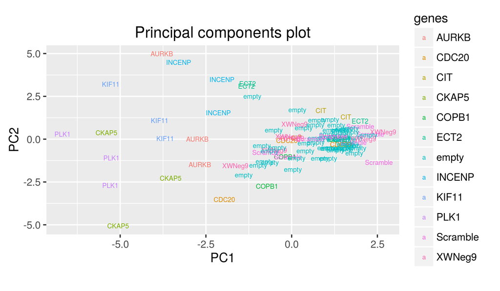

```r
data_for_PCA <- data_for_PCA %>%
                dplyr::select(class, well, z_score) %>%
                spread(key = class, value = z_score)

PCA <- prcomp(data_for_PCA[, -1], center = TRUE, scale. = TRUE)


genes <- input_data %>%
         group_by(well) %>%
          dplyr::summarize(gene = unique(Gene.Symbol))

genes <- ifelse(is.na(genes$gene), "empty", genes$gene)

dataGG = data.frame(PC1 = PCA$x[,1], PC2 = PCA$x[,2],
                    PC3 = PCA$x[,3], PC4 = PCA$x[,4],
                    genes)

pl <- (ggplot(dataGG, aes(x = PC1, y = PC2, color =  genes))
      + geom_text(aes(label = genes), size = I(2))
      + coord_fixed(ratio = (PCA$sdev^2)[2] / (PCA$sdev^2)[1])
      + ggtitle("Principal components plot")
      )

pl
```

We can see, for example, that the control wells cluster together. Note that it is easy to turn this plot into an interactive version using `ggplotly` from the *[plotly](http://cran.fhcrc.org/web/packages/plotly/index.html)*.

```r
if(!("plotly" %in% installed.packages()[,1])){
  install.packages("plotly")
}

library(plotly)
ggplotly(pl)
```

## 7.3 Variable importance for the principal components

The first PC nicely separates wells containing various controls from the ones treated with siRNAs. As every component is simply a weighted sum of the original variables, we can inspect these weights (called “loadings”) to see which classes “drive” the components and try to interpret what we find.

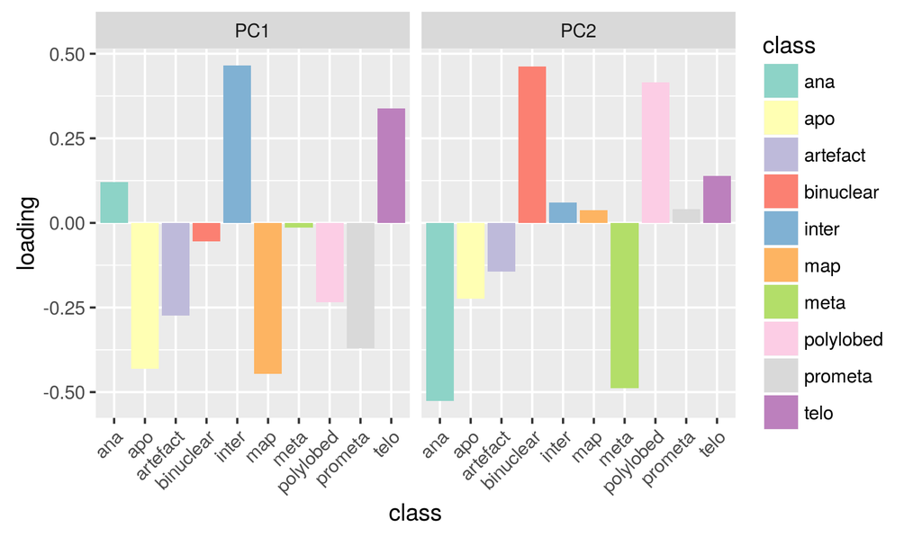

```r
loadings <- PCA$rotation[, 1:2]
loadings_gg <- loadings %>%
               as.data.frame() %>%
               rownames_to_column(var = "class") %>%
               dplyr::select(class, PC1, PC2) %>%
               gather( key = "comp", value = "loading", PC1:PC2)

ggplot(loadings_gg, aes(x = class, y = loading, fill = class)) +
      facet_wrap( ~ comp) +
      geom_bar(stat = "identity", position = "identity") +
      theme(axis.text.x = element_text(angle = 45, hjust = 1)) +
      scale_fill_brewer(type = "qual", palette = "Set3")
```

We can see that e.g. the “inter” and the “map/prometa” classes as well as the “apo” class are important for PC1. The map and prometa classes combined define cells that are in mitotic delay/arrest, while the interphase class defines a control category.

So a possible explanation for PC1 would be that it separates wells with cells in mitotic arrest/delay (or apoptotic cells) from control wells with many cells in the interphase phase (c.f. Figure 1 of Neumann et al. (2010)).

The second principal component seems to separate wells that contain mainly cells in ana–/metaphase from wells that predominantly contains cells with strange shape phenotypes.

## 7.4 Correlation circles and PCs for hit calling

The loadings are closely related (up to a scaling factor) to the correlation of the original variables with the computed principal components. We can investigate this relationship by plotting the correlations of the original variables with the components in a circle.

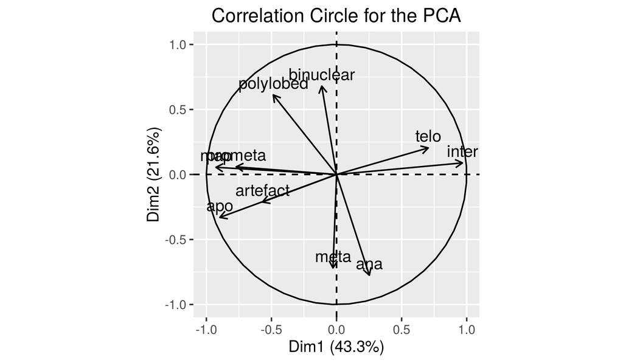

```r
fviz_pca_var(PCA, col.circle="black", title="Correlation Circle for the PCA") + coord_equal()
```

PC2 is positively correlated with the strange phenotypes. Thus, we could potentially use the first and second PC to call hits. For example, PLK1, which is very far from the controls in PC1 coordinates is known to be important during the M–phase of the cell cycle. Thus, if this gene is inhibited, the mitosis does not work properly any more and the cells are stuck in the cell cycle or undergo apoptosis.

# 8 Plate heatmap of apoptosis proportions

Heatmaps are a powerful of visualizing large, matrix-like datasets and giving a quick overview over the patterns that might be in there. There are a number of heatmap drawing functions in R; one that is convenient and produces good-looking output is the function `pheatmap` from the eponymous package.

However, here we will use ggplot to create the heatmap. We first join all the well IDs to the data, so that we can plot missing values in a uniform fashion.

Then we extract the row (letters) and column (numbers) from the well ID and finally map the rows to the y–axis, the columns to the x–axis and the color fill to the percentage values for apoptosis

The heatmap plot shows that well D08 contains a high percentage of apoptotic cells compared to the other wells.

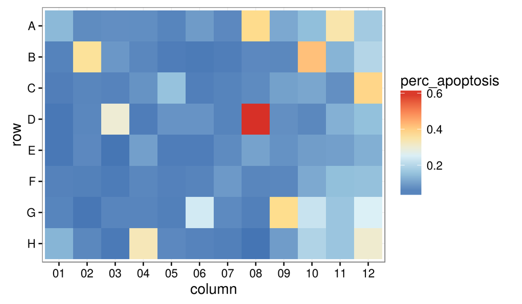

```r
dat_rows <- toupper(letters[1:8])
dat_cols <- c(paste0("0",seq(1:9)),seq(10,12))
wells <- data.frame( well = paste0(outer(dat_rows, dat_cols, paste0), "_01"),
                     stringsAsFactors = FALSE)

data_for_heatmap <- arrange(full_join(data_for_PCA, wells), well) %>%
                    select(well, apo) %>%
                    extract(well, into = c("row", "column"),
                            regex = "([A-Z])([0-9]{2})", remove = FALSE) %>%
                    mutate(perc_apoptosis = logistic(apo)) %>%
                    mutate(row = factor(row,
                           levels = sort(unique(row), decreasing = TRUE)))
theme_set(theme_bw())
heatmap <- (ggplot(data_for_heatmap, aes(column, row))
          + geom_tile(aes(fill = perc_apoptosis))
          + scale_fill_distiller(type = "seq", palette = "RdYlBu"))

heatmap
```

# 9 Background information

The following sections contain additional background information on the techniques used in this tutorial.

## 9.1 Long and wide data tables, tidy data, split-apply-combine

In a nutshell, a dataset is a collection of values, usually either numbers (if quantitative) or strings (if qualitative). Values are organized in two ways: Every value belongs to a variable and an observation.

A variable contains all values that measure the same underlying attribute (like height, temperature, duration) across units. An observation contains all values measured on the same unit (like a person, or a day, or a race) across attributes.

Now, a tidy data frame organizes the data in such a way that each observation corresponds to an single line in the data set. This representation is often referred to as a “long” data table.

In general, a long data table is the most appropriate format for downstream analysis, although a wide representation is better for viewing the data. For a thorough discussion of this topic see the paper by Hadley Wickham (2014).

In any case, we often need to move between these different shapes. The *[tidyr](http://cran.fhcrc.org/web/packages/tidyr/index.html)* has two main functions that allows us to go back and forth:

- `gather()` takes multiple columns, and gathers them into key–value pairs: it makes “wide” data longer.
- `spread()` takes two columns (key & value) and spreads into multiple columns, it makes “long” data wider.

Having tidy data frames, we can employ a **split–apply–combine** strategy for data analysis. What this means is that we first group our individual observations by one or more factors (*split* operation), then *apply* computations to each group and then combine the results into new data frame that contains one line per group.

## 9.2 The chaining operator

For this, we use the chaining (or piping) operator `%>%`. `x %>% f(y)` is simply `f(x, y)`, so one can use it to rewrite multiple operations in such a way that they can be read from left–to–right, or top–to–bottom. A simple example will make that clear: We create two vectors and calculate Euclidean distance between them. Instead of the usual way:

```r
x1 <- 1:5; x2 <- 2:6
sqrt(sum((x1-x2)^2))
```

```
   [1] 2.24
```

We can use the piping operator

```r
(x1-x2)^2 %>%
sum() %>%
sqrt()
```

```
   [1] 2.24
```

Which makes the set of operations much easier to digest and understand.

## 9.3 Plotting in R with ggplot2

*[ggplot2](http://cran.fhcrc.org/web/packages/ggplot2/index.html)* is a package by Hadley Wickham that implements the idea of **grammar of graphics**: There is a grammar to the composition of graphical components in and by directly controlling that grammar, you can generate a large set of graphics tailored to your particular needs.

The central concept of the approach is that plots convey information through various aspects of their aesthetics. Aesthetics are mappings from the data to something you can visually perceive. Some aesthetics that plots use are:

- x position
- y position
- size of elements
- shape of elements
- color of elements

The elements in a plot are geometric shapes, like

- points
- lines
- line segments
- bars
- text

Comprehensive documentation for the package can be found [on its website](http://ggplot2.org). The online documentation includes example use cases for a lot of the graphic types and is an invaluable resource when creating figures.

In *[ggplot2](http://cran.fhcrc.org/web/packages/ggplot2/index.html)* each component is added to the plot as a layer, hence you might start with a simple mapping of the raw data to the x– and y–axes, creating a scatterplot. A second layer may the be added by coloring the points according to a group they belong to and so on.

The values represented in the plot are the product of various statistics. If you just plot the raw data, you can think of each point representing the identity statistic.

Bar charts however, often represent the mean or a count statistic, while histograms are bar charts where the bars represent the binned count or density statistics and so on.

Let’s start by creating a simple plot: Data from an enzyme-linked immunosorbent assay (ELISA) assay. The assay was used to quantify the activity of the enzyme deoxyribonuclease (DNase), which degrades DNA. The data are assembled in the R object `DNase`, which conveniently comes with base R. `DNase` is a dataframe whose columns are `Run`, the assay run; `conc`, the protein concentration that was used; and `density`, the measured optical density.

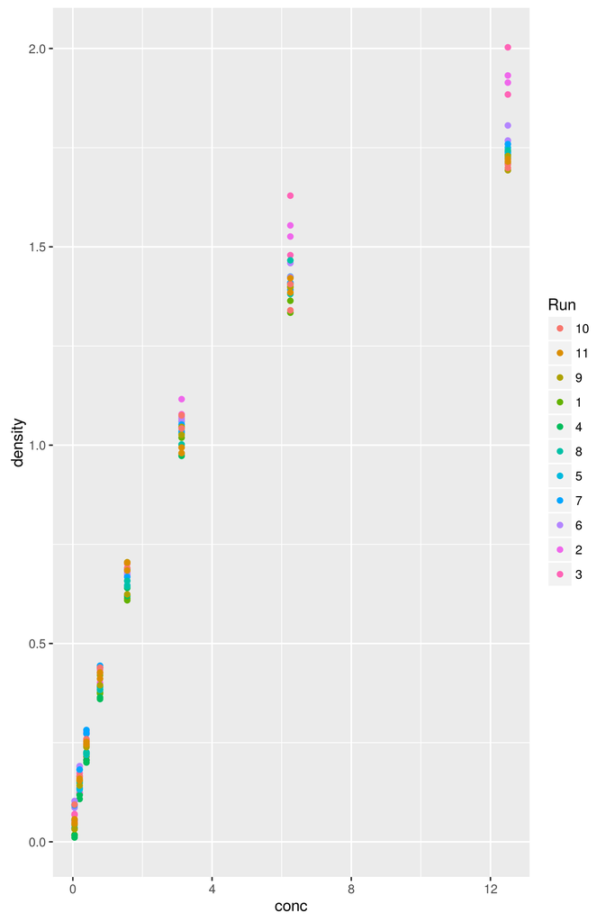

```r
ggplot(DNase, aes(x = conc, y = density, color = Run)) + geom_point()
```

We just wrote our first `sentence` using the grammar of graphics. Let us deconstruct this sentence. First, we specified the dataframe that contains the data, `DNase`. Then we told `ggplot` via the aesthetics `aes` argument which variables we want on the $x$- and $y$-axes, respectively and mapped the run number to the color aesthetic. Finally, we stated that we want the plot to use points, by adding the result of calling the function `geom_point`.

## 9.4 Principal component analysis (PCA) to for data visualization

PCA is primarily an exploratory technique which produces maps that show the relations between the variables and between observations in a useful way. It proceeds by computing principal components of the original data, which are *linear combinations* of the variables originally measured.

To understand what a linear combination really is, we can take an analogy, when making a healthy juice mix, you can follow a recipe.

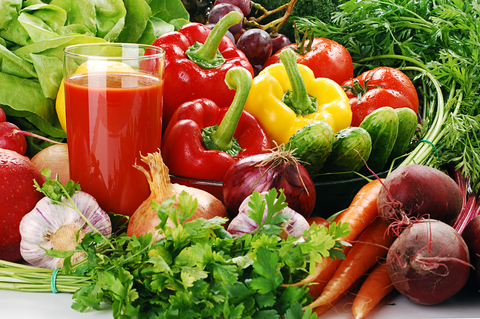

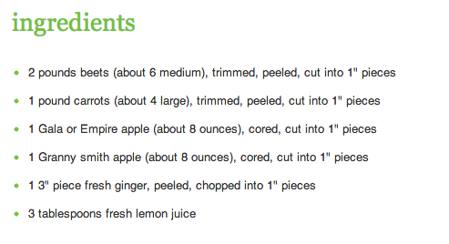

$$V=2\times \mbox{ Beets }+ 1\times \mbox{Carrots } +\frac{1}{2} \mbox{ Gala}+ \frac{1}{2} \mbox{ GrannySmith}
+0.02\times \mbox{ Ginger} +0.25 \mbox{ Lemon }$$
This recipe is a linear combination of individual juice types (the original variables). The result is a new variable $V$, the coefficients $(2,1,\frac{1}{2},\frac{1}{2},0.02,0.25)$ are called the *loadings*.

A linear combination of variables defines a line in higher dimensions in the same way as e.g. a simple linear regression defines a line in the scatterplot plane of two dimensions.

There are many ways to choose lines onto which we project the data. PCA chooses the line in such a way that the distance of the data points to the line is minimized, and the variance of the orthogonal projections of the data points along the line is maximized.

Spreading points out to maximize the variance of the projected points will show more “information”.

For computing multiple axes, PCA finds the axis showing the largest variability, removing the variability in that direction and then iterating to find the next best orthogonal axis so on.

[output not shown]

# References

Neumann, Beate, Thomas Walter, Jean-Karim H’eric ’e, Jutta Bulkescher, Holger Erfle, Christian Conrad, Phill Rogers, et al. 2010. “Phenotypic Profiling of the Human Genome by Time-Lapse Microscopy Reveals Cell Division Genes.” *Nature* 464 (7289). Springer Nature: 721–27. doi:10.1038/nature08869.

Sommer, C., M. Held, B. Fischer, W. Huber, and D. W. Gerlich. 2013. “CellH5: A Format for Data Exchange in High-Content Screening.” *Bioinformatics* 29 (12). Oxford University Press (OUP): 1580–2. doi:10.1093/bioinformatics/btt175.

Wickham, Hadley. 2014. “Tidy Data.” *Journal of Statistical Software*. https://www.jstatsoft.org/article/view/v059i10. https://www.jstatsoft.org/article/view/v059i10.